# Week 8: Mixture Models

PS 818 - Statistical Models

Anton Strezhnev

strezhnev@wisc.edu

University of Wisconsin-Madison

October 20, 2025

$$\require{cancel}
\DeclareMathOperator*{\argmin}{arg\,min}$$

$$\DeclareMathOperator*{\argmax}{arg\,max}$$

# Previously

- **Multilevel/Hierarchical models**
  - Impose **structure** on parameters by way of prior distributions
  - What structure?
    - Information from **grouping** (partial pooling/‘random effects’)
    - Information from **time** (random-walk prior)
  - Strength of prior governs the degree of pooling/smoothing

# This week

- **“Exploratory” modeling**
  - Unsupervised “clustering” algorithms
  - K-means clustering
  - Bayesian mixture models
  - Obtaining MLEs or posterior modes via Expectation-Maximization
- **Topic modeling**
  - A mixture model for text:
  - Documents have a topic **distribution**
  - Define a DGP for each word as a function of the document topic distribution and a topic-specific word distribution.
  - Flexible way of representing documents via a lower-dimensional summary.

# Finite Mixture Models

- In conventional **regression** models, we assume a known distribution for the outcome given a set of covariates
  - The covariates could be something like a discrete “group” label (e.g. $X_i = x$)
- In this setting, conditional on $X_i$, we would model each $Y_i$ with a known distribution (e.g. Normal)

  $$Y_i | X_i = x \sim \text{Normal}(\mu_{x}, \sigma^2_{x})$$

$\mu_{x}$ and $\sigma^2_{x}$ are the mean and variance parameters associated with the group $X_i = x$.

- Now imagine that the group indicators are **not observed** but instead rather **latent parameters**
  - We can do inference on these parameters conditional on the observed data and the model.

# Finite Mixture Models

- In a **finite** mixture model, we assume that the outcome distribution for each observation $i$ is governed by some discrete latent indicator $z_i \in \{1, 2, \dotsc, K\}$
  - $z_1, z_2, \dotsc, z_N$ are i.i.d. $\sim \text{Categorical}(\pi)$
- Conditional on the latent variable $z_i = k$, the outcome distribution is known.
- For example, in a **gaussian** finite mixture model, we assume

  $$Y_i | z_i = k \sim \text{Normal}(\mu_{k}, \sigma^2_{k})$$
- But unconditionally, $Y_i$ has a **mixture** distribution in that its density is a weighted average of the component densities.
- In a **gaussian** finite mixture model, we have:

  $$Y_i \sim \sum_{k=1}^K \pi_k \times \text{Normal}(\mu_{k}, \sigma^2_{k})$$

  where $\pi_k = Pr(z_i = k)$
- Our goal is to estimate the cluster means/variances for each cluster and the mixing proportions using likelihood inference.

# Penguins!

- For our running example, we’ll look at the `palmerpenguins` dataset which contains measurements on three species of penguins in the Palmer Archipelago in Antarctica

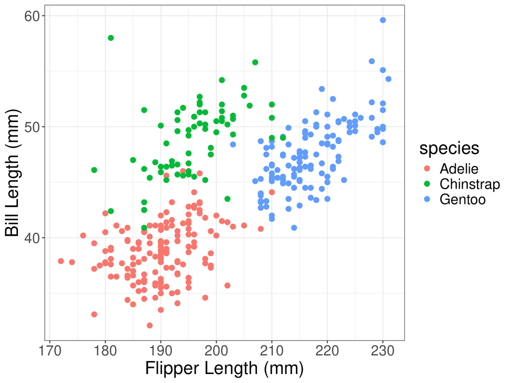

# Clustering

- Suppose we didn’t observe the labels, could we still recover the latent “clusters” in the data?

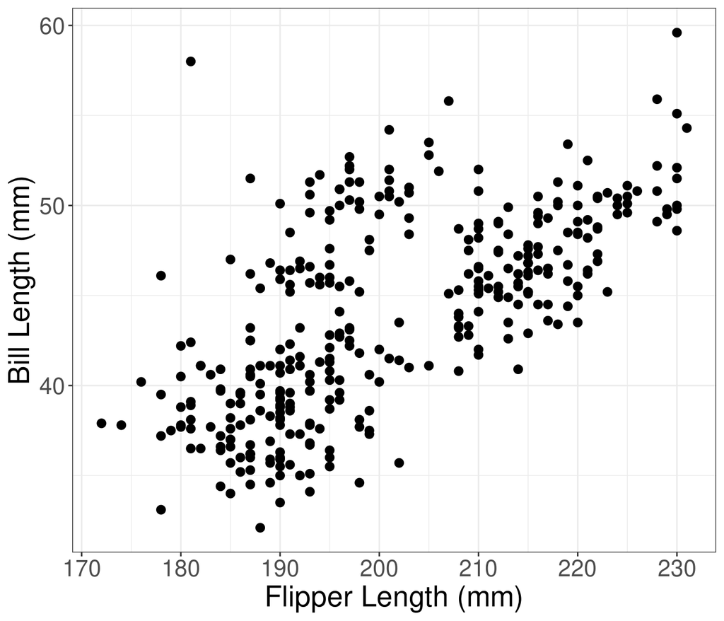

# K-means

- A simple algorithm for generating clusters that has no underlying probabilistic model is the **K-means algorithm**
  - Straightforward to implement and still surprisingly popular and effective for a “first cut” at the data.
- **K-means algorithm**
  1. Initialize $K$ distinct clusters by randomly assigning points to one of the $k$ groups
  2. Calculate $\mu_k$ as the mean of $Y_i$ in observations in cluster $k$.
  3. Reassign each point to the cluster $k$ that has the smallest distance between $Y_i$ and $\mu_k$.
  4. Repeat 2-3 until no points change their assignments.

# K-means example

- Let $K = 3$ and randomly pick three initial $\mu_k$

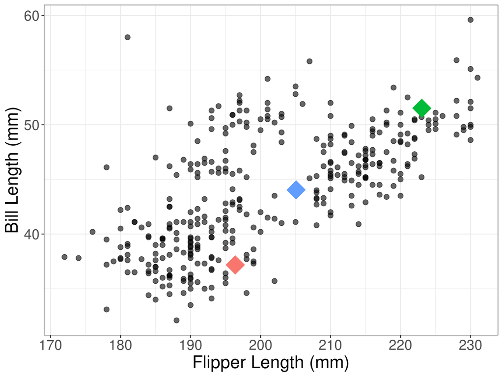

# K-means example

- Assign each penguin to the cluster with the nearest cluster centroid.

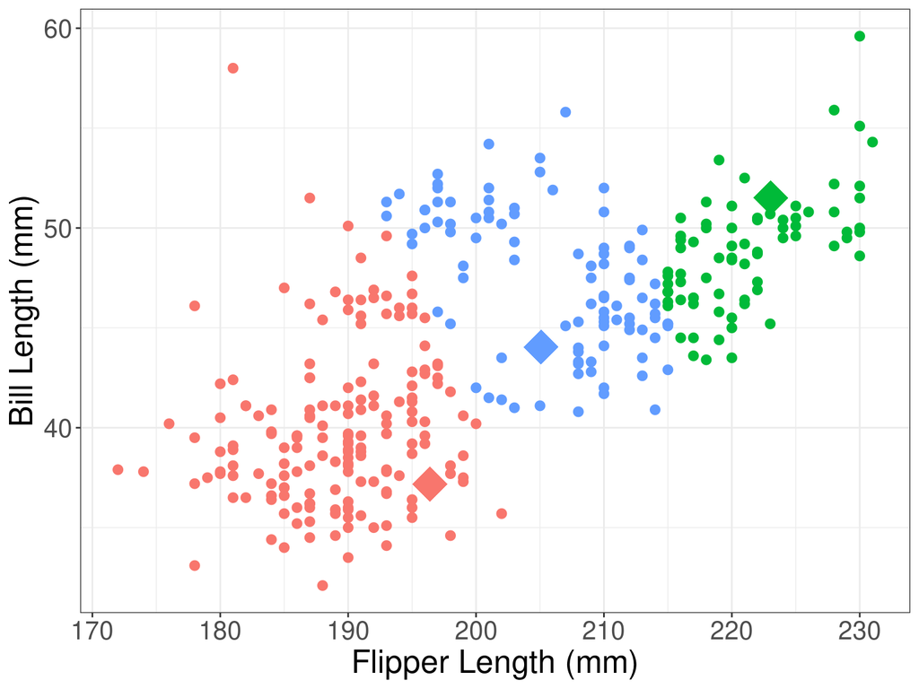

# K-means example

- Recompute the cluster means

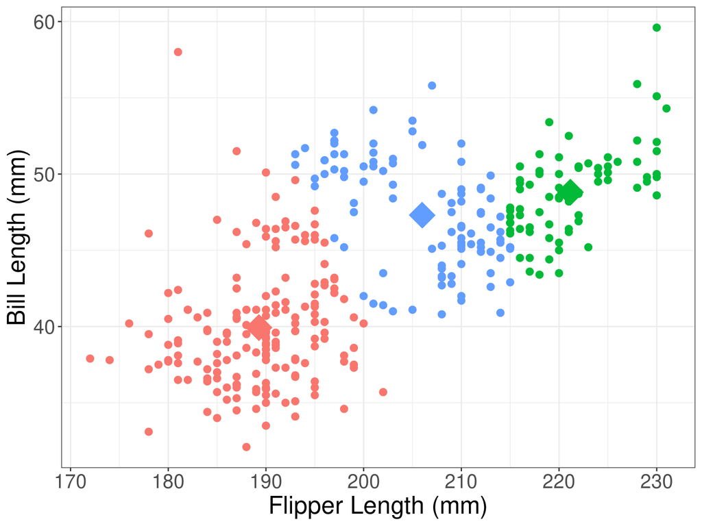

# K-means example

- Re-label the points

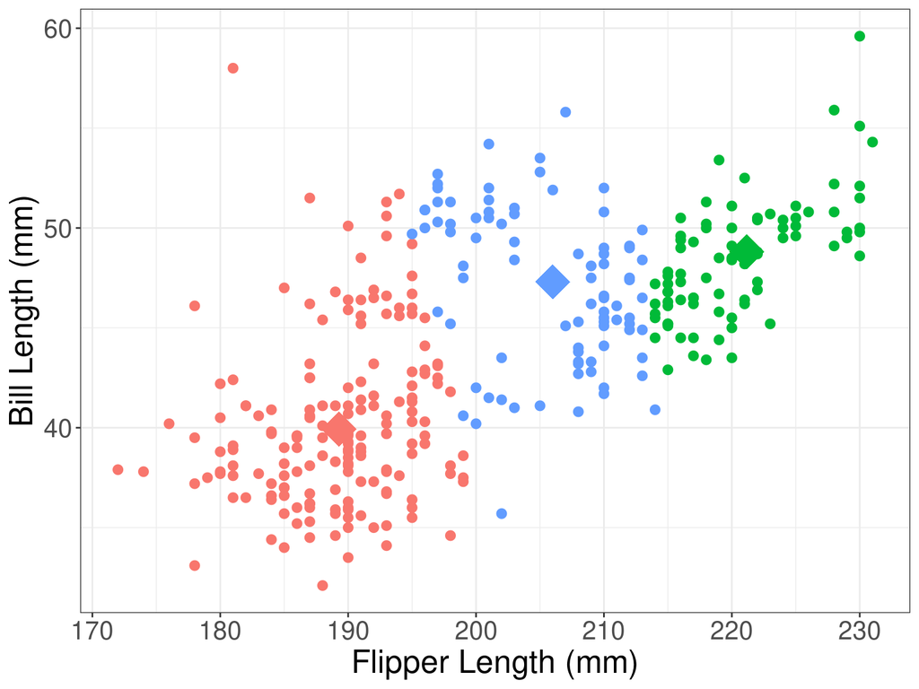

# K-means example

- Iterate until convergence

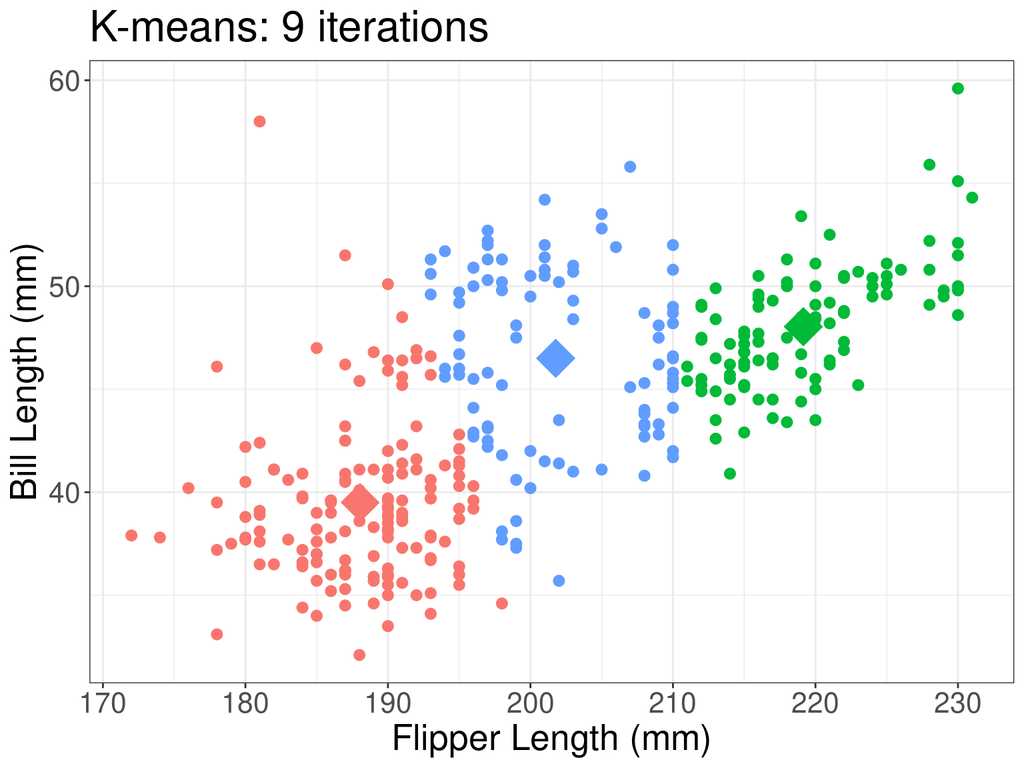

# K-means example

- Note some sensitivity to the choice of distance metric. Here’s what it looks like if we standardize each $Y$ by it standard deviation.

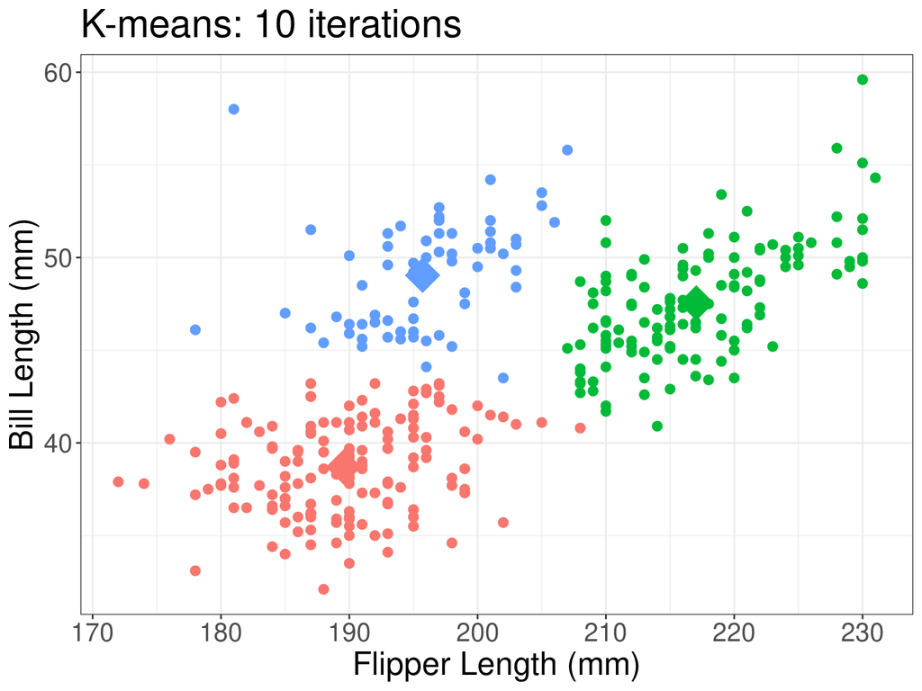

# K-means example

- How do our clusters compare to the **actual** categories? Surprisingly well!

```
    Adelie Chinstrap Gentoo
  1    146         5      0
  2      1         4    122
  3      4        59      1
```

- But the clusters themselves don’t have any underlying interpretation or meaning
  - We **assign** the interpretation to them through inspection!

# K-means

- Advantages
  - Easy to implement, fast updating steps and quick convergence.
- Disadvantages
  - Multimodality (we can’t really solve this one!)
  - Choice of distance metric matters.
  - Hard to make sense of outcomes that aren’t in $\mathbb{R}^{d}$ (e.g. binary/discrete outcomes)
- With conventional K-means, we have no underlying probability model – each unit is assigned to a single cluster.
  - Sometimes called **“hard”** K-means.
- We can instead implement an approach sometimes referred to as a “soft” K-means algorithm
  - Our target of inference is the **probability** that a unit belongs to each cluster.

# Gaussian Mixture Models

- Assume **latent variables** $z = \{z_1, z_2, \dotsc, z_N\}$

  $$z_i \underset{\text{i.i.d.}}{\sim} \text{Categorical}(\pi)$$
- Then, the outcome vector $Y_i$ has a multivariate gaussian distribution conditional on $Z_i = k$

  $$Y_i | z_i = k \sim \text{Normal}(\mu_{k}, \Sigma_{k})$$
- Our goal is to infer $\mu_k$ and $\Sigma_k$ for each cluster
  - And conditional on these estimates, we can obtain the cluster probabilities $Pr(Z_i = k | Y_i)$

# Expectation-Maximization

- Let’s write down the marginal likelihood, marginalizing out the latent parameters:

  $$\mathcal{L}(\mu, \Sigma, \pi; \mathbf{Y}) = \prod_{i=1}^N \sum_{k=1}^K f(Y_i| \mu_{k}, \Sigma_{k}, Z_i = k) \times p(Z_i = k | \pi)$$
- This is a tricky likelihood to maximize - if we take the log, we get a log of a sum (which doesn’t simplify as neatly as a log of a product)

  $$\ell(\mu, \Sigma, \pi ; \mathbf{Y}) = \sum_{i=1}^N \log\bigg(\sum_{k=1}^K \pi_k \times \mathcal{N}(Y_i| \mu_{k}, \Sigma_{k}) \bigg)$$
- Suppose we knew the $Z_i$ as well (they were like “data”), then the “complete” log-likelihood would be easier to maximize!

$$\ell(\mu, \Sigma, \pi ; \mathbf{Y}, \mathbf{Z}) = \sum_{i=1}^N \sum_{k=1}^K \log\bigg( \pi_k^{I(Z_i = k)} \times \mathcal{N}(Y_i| \mu_{k}, \Sigma_{k})^{I(Z_i = k)} \bigg)$$

# Expectation-Maximization

- The **Expectation-Maximization** algorithm is another iterative method for obtaining a maximum likelihood estimate (or maximum a posteriori (MAP) in a Bayesian setting) when the likelihood consists of a sum/integral over the distribution of some **latent variables**
  - It uses the idea of iteratively optimizing a **lower bound** on the likelihood until convergence is reached.
  - The key trick is **Jensen’s inequality**. For a **concave** function like the logarithm:

  $$\log(E[X]) \ge E[\log(X)]$$
- Consider the general setting where we have a parameter $\theta$, data $\mathbf{X}$ and discrete latent variables $Z$
- We want to optimize the log-likelihood:

  $$\ell(\theta; \mathbf{X}) = \log \sum_{\mathbf{Z}} f(\mathbf{X}, \mathbf{Z} | \theta) = \log \sum_{\mathbf{Z}} f(\mathbf{X} | \mathbf{Z}, \theta) p(\mathbf{Z} | \theta)$$

# Expectation-Maximization

- Instead of optimizing the log-likelihood, let’s try to come up with a lower-bound. Define an arbitrary distribution on the latent variables $q(\mathbf{Z})$.
- Multiply by 1:

  $$\ell(\theta; \mathbf{X}) = \log \sum_{\mathbf{Z}} f(\mathbf{X} | \mathbf{Z}, \theta) p(\mathbf{Z} | \theta) \frac{q(\mathbf{Z})}{q(\mathbf{Z})}$$
- Rearranging terms, we can see that this can be written as an expectation over the distribution $q$

  $$\ell(\theta; \mathbf{X}) = \log E_{q} \bigg[\frac{ f(\mathbf{X} | \mathbf{Z}, \theta) p(\mathbf{Z} | \theta)}{q(\mathbf{Z})}\bigg]$$
- By **Jensen’s inequality**, we have a lower bound

  $$\ell(\theta; \mathbf{X}) \ge E_{q} \bigg[ \log \bigg(\frac{ f(\mathbf{X} | \mathbf{Z}, \theta) p(\mathbf{Z} | \theta)}{q(\mathbf{Z})}\bigg)\bigg]$$

# Expectation-Maximization

- And by properties of logs, our lower-bound is:

  $$\ell(\theta; \mathbf{X}) \ge E_{q}[\log(f(\mathbf{X}|\mathbf{Z}, \theta))] + E_{q}[\log(f\mathbf{Z}| \theta))] - E_{q}[\log(q(\mathbf{Z})]$$
- We can optimize this **iteratively** by switching between finding an optimal distribution $q^{(t+1)}$ given parameter values $\theta^{(t)}$ and finding parameter values $\theta^{(t+1)}$ given an existing choice of $q^{(t)}$.
  1. **Expectation** step: Find $q^{(t+1)}$ (what distribution are we taking the expectation over)
  2. **Maximization** step: Find $\theta^{(t+1)}$ (given our $q$ distribution, what is the value of the parameter values that maximizes the lower bound).

# E-step

- Can we find a closed-form “optimal” solution for our update $q^{(t+1)}$ given $\theta^{(t)}$?
  - Yes, find the $q$ that makes the inequality an equality!

  $$\ell(\theta^{(t)}; \mathbf{X}) \ge E_{q} \bigg[ \log \bigg(\frac{ f(\mathbf{X} | \mathbf{Z}, \theta^{(t)}) p(\mathbf{Z} | \theta^{(t)})}{q(\mathbf{Z})}\bigg)\bigg]$$

  $$\ell(\theta^{(t)}; \mathbf{X}) \ge \sum_{\mathbf{Z}}\log \bigg(\frac{ f(\mathbf{X} | \mathbf{Z}, \theta^{(t)}) p(\mathbf{Z} | \theta^{(t)})}{q(\mathbf{Z})}\bigg) q(\mathbf{Z})$$

# E-step

- Let’s try to get the $\mathbf{Z}$ out of the log. Start by factoring the joint distribution in the numerator conditioning on $\mathbf{X}$ instead of $\mathbf{Z}$

  $$\ell(\theta^{(t)}; \mathbf{X}) \ge \sum_{\mathbf{Z}}\log \bigg(\frac{ f(\mathbf{Z} | \mathbf{X}, \theta^{(t)}) p(\mathbf{X} | \theta^{(t)})}{q(\mathbf{Z})}\bigg) q(\mathbf{Z})$$
- Now we can see the optimal choice for $q^{t+1}$ revealed to us. Suppose we plug in $q = f(\mathbf{Z} | \mathbf{X}, \theta^{(t)})$, the conditional distribution of $Z$ given $X$ and $\theta^{(t)}$:

  $$\ell(\theta^{(t)}; \mathbf{X}) \ge \sum_{\mathbf{Z}}\log( p(\mathbf{X} | \theta^{(t)}) \times f(\mathbf{Z} | \mathbf{X}, \theta^{(t)})$$
- The logged term no longer depends on $\mathbf{Z}$, so pull it out of the sum

  $$\ell(\theta^{(t)}; \mathbf{X}) \ge \log( p(\mathbf{X} | \theta^{(t)}) \times \sum_{\mathbf{Z}} f(\mathbf{Z} | \mathbf{X}, \theta^{(t)})$$

# E-step

- The sum is equal to $1$ (sum over a PMF/PDF) and we’re left with the definition of the marginal log-likelihood, so this expression holds with *equality*

  $$\ell(\theta^{(t)}; \mathbf{X}) = \log( p(\mathbf{X} | \theta^{(t)})$$
- So our choice of distribution over which to take the expectation of the joint likelihood is $q^{(t+1)} = f(\mathbf{Z} | \mathbf{X}, \theta^{(t)})$

# M-step

- Let’s go back to our lower bound - for a given value of $q^{(t)}$, we want to find the $\theta^{(t+1)}$ that maximize the “complete data” log-likelihood

  $$\ell(\theta; \mathbf{X}) \ge E_{q^{(t)}}[\log(f(\mathbf{X}|\mathbf{Z}, \theta))] + E_{q^{(t)}}[\log(f(\mathbf{Z}| \theta))] - E_{q^{(t)}}[\log(q^{(t)}(\mathbf{Z})]$$
- Since the third term doesn’t depend on $\theta$, we only need to worry about the first two.
  - This is sometimes called the “Q-Function” $Q(\theta | \theta^{(t)})$ or the expected “complete data” log-likelihood

  $$Q(\theta | \theta^{(t)}) = E_{\mathbf{Z}|\mathbf{X}, \theta^{(t)}}[\log(f(\mathbf{X}, \mathbf{Z}| \theta))]$$
- The M-step sets $\theta^{(t+1)}$ to the value of $\theta$ that maximizes this Q-function

  $$\theta^{(t+1)} = \argmax_{\theta} Q(\theta | \theta^{(t)})$$

# Deriving EM for the GMM

- For current values of $\mu^{(t)}$, $\Sigma^{(t)}$, $\pi^{(t)}$, let’s derive the $Q$ function.
- We’ll start by deriving the conditional distribution $z_i | Y_i, \mu^{(t)}, \Sigma^{(t)}, \pi^{(t)}$ using Bayes’ rule

  $$p(z_i = k | Y_i, \mu^{(t)}, \Sigma^{(t)}, \pi^{(t)}) = \frac{p(z_i = k | \pi_k^{(t)}) f(Y_i | \mu^{(t)}, \Sigma^{(t)}, z_i = k)}{f(Y_i | \mu^{(t)}, \Sigma^{(t)})}$$
- Given $z_i = k$, we know the distribution is normal at mean $\mu_{k}^{(t)}$ and variance $\Sigma_{k}^{(t)}$. And the denominator is just the marginal

  $$\gamma_i^k = p(z_i = k | Y_i, \mu^{(t)}, \Sigma^{(t)}, \pi^{(t)}) = \frac{\pi_k^{(t)} \times \mathcal{N}(Y_i | \mu_k^{(t)}, \Sigma_k^{(t)})}{\sum_{j=1}^K \pi_j^{(t)} \times \mathcal{N}(Y_i | \mu^{(t)}_j, \Sigma^{(t)}_j)}$$
- These weights, $\gamma_i^k$ are sometimes called the “responsibility” parameters as they denote the extent to which each cluster is “responsible” for an observation.

# Deriving EM for the GMM

- Recall the “complete likelihood”

  $$\ell(\mu, \Sigma, \pi ; \mathbf{Y}, \mathbf{Z}) = \sum_{i=1}^N \sum_{k=1}^K\log\bigg( \pi_k^{I(Z_i = k)} \times \mathcal{N}(Y_i| \mu_{k}, \Sigma_{k})^{I(Z_i = k)} \bigg)$$
- Simplify it a bit

  $$\ell(\mu, \Sigma, \pi ; \mathbf{Y}, \mathbf{Z}) = \sum_{i=1}^N \sum_{k=1}^K I(Z_i = k)\log(\pi_k) + \sum_{i=1}^N \sum_{k=1}^KI(Z_i = k) \log \mathcal{N}(Y_i| \mu_{k}, \Sigma_{k})$$
- Now, taking the expectation over $Z_i$, the only component that is not a constant is $I(Z_i = k)$ and $E[I(Z_i = k)] = p(Z_i = k)$ (fundamental bridge).
  - And we got that (conditional) expectation in the previous section: $\gamma_i^k$
- So our Q function is

  $$Q(\theta | \theta^{(t)}) = \sum_{i=1}^N \sum_{k=1}^K \gamma_i^k\log(\pi_k) + \sum_{i=1}^N \sum_{k=1}^K \gamma_i^k \log \mathcal{N}(Y_i| \mu_{k}, \Sigma_{k})$$

# Deriving EM for the GMM

- Closed form solutions are straightforward to obtain for the M-step (and follow from weighted regression)

  $$n_k = \sum_{i=1}^N \gamma_i^k$$
  $$\pi_k = \frac{n_k}{N}$$
  $$\mu_k = \frac{1}{n_k}\sum_{i=1}^N \gamma_i^k Y_i$$
  $$\Sigma_k = \frac{1}{n_k} \sum_{i=1}^N \gamma_i^k (Y_i - \mu_{k})(Y_i - \mu_{k})^{\prime}$$

# Implementing EM

```r
gmm_loglik <- function(Y, K, mu, sigma, pi){
  # Log-likelihood of each Y
  lik_normal <- matrix(nrow=nrow(Y), ncol=K)
  for(k in 1:K){
    lik_normal[,k] <- mvtnorm::dmvnorm(Y, mu[k,], sigma[[k]])
  }
  # Log of the sums
  log_likelihood <- sum(apply(lik_normal, 1, function(x) log(sum(x*pi))))
  return(log_likelihood)
}
```

# Implementing EM

```r
gmm_estep_gamma <- function(Y, K, mu, sigma, pi){
  # Calculate unnormalized gamma_k for each k
  gamma <- matrix(nrow=nrow(Y), ncol=K)
  for (k in 1:K){
    gamma[,k] <- pi[k]*mvtnorm::dmvnorm(Y, mu[k,], sigma[[k]])
  }
  # Normalize the gammas (denominator)
  gamma <- gamma/rowSums(gamma)
  return(gamma)
}
```

# Implementing EM

```r
sigma_update <- function(Y, K, mu_k, gamma, n_k){ # Super inefficient but works
  # For each k
  sigma <- list()
  for (k in 1:K){
    sigma[[k]] <- matrix(data=0, nrow=ncol(Y), ncol=ncol(Y)) # blank matrix
    for (n in 1:nrow(Y)){
      sigma[[k]] <- sigma[[k]] + gamma[n,k]*outer(Y[n,] - mu_k[k,], Y[n,] - mu_k[k,])
    }
    sigma[[k]] <- sigma[[k]]/n_k[k]
  }
  return(sigma)
}
```

# Implementing EM

```r
gmm_em <- function(Y, K, maxit=5000, tol=1e-8, verbose=F){
  D <- ncol(Y) # Number of dimensions
  ## Initialize the parameters (pick some reasonable starting points)
  mu_k <- MASS::mvrnorm(K, colMeans(Y), Sigma = var(Y)) # Matrix of means
  sigma_k <- list() # list of covariances
  for (k in 1:K){
    sigma_k[[k]] <- var(Y)
  }
  pi <- rep(1/K, K)
  curr_lik <- gmm_loglik(Y, K, mu_k, sigma_k, pi) #Evaluate current likelihood
  if(verbose) print(str_c("Log-Likelihood: ", curr_lik))
  for(iter in 2:maxit){
    # E-step
    gamma <- gmm_estep_gamma(Y, K, mu_k, sigma_k, pi)
    # M-step
    n_k <- colSums(gamma)
    pi <- n_k/sum(n_k)
    for(k in 1:K){
        mu_k[k,] <- colSums(gamma[,k]*Y)/n_k[k]
    }
    sigma_k <- sigma_update(Y, K, mu_k, gamma, n_k)
    # Check convergence
    new_lik <- gmm_loglik(Y, K, mu_k, sigma_k, pi)
    if (abs(new_lik - curr_lik) < tol){
      gamma <- gmm_estep_gamma(Y, K, mu_k, sigma_k, pi)
      if(verbose)print(str_c("Log-Likelihood: ", curr_lik))
      if(verbose) print(str_c("Log-Likelihood: ", new_lik))
      if(verbose)print("Complete!")
      break
    }else{
      curr_lik <- new_lik
    }
    if (iter %% 10 == 0&verbose){
      print(str_c("Log-Likelihood: ", new_lik))
    }
  }
  if(iter == maxit){
    print("Error: Maxit reached")
  }
  return(list(mu= mu_k, sigma = sigma_k, pi=pi, gamma=gamma, log_lik = new_lik))
}
```

# Implementing EM

```r
set.seed(53703)
penguins_em_3 <- gmm_em(Y=as.matrix(penguins_complete %>% select(flipper_length_mm, bill_length_mm)), K=3, verbose=T)
```

```
[1] "Log-Likelihood: -2520.55581411815"
[1] "Log-Likelihood: -2253.13711539857"
[1] "Log-Likelihood: -2245.27835692481"
[1] "Log-Likelihood: -2244.41244264126"
[1] "Log-Likelihood: -2244.23450418424"
[1] "Log-Likelihood: -2244.21996208028"
[1] "Log-Likelihood: -2244.219302562"
[1] "Log-Likelihood: -2244.21927688568"
[1] "Log-Likelihood: -2244.21927591688"
[1] "Log-Likelihood: -2244.21927590631"
[1] "Log-Likelihood: -2244.21927589871"
[1] "Complete!"
```

# Visualizing EM

- Now our point labels have **probabilities** attached

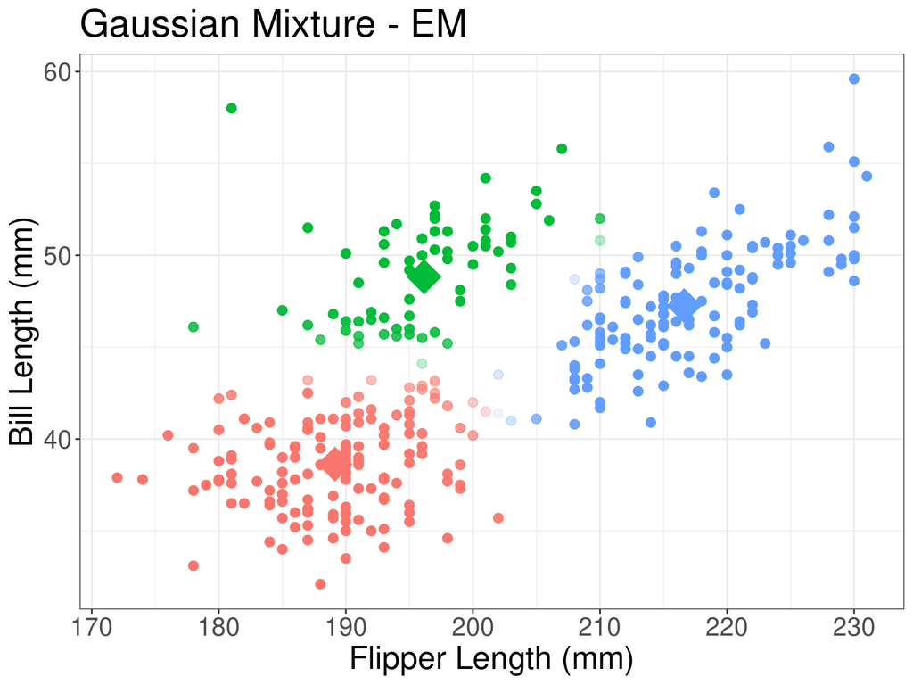

# Visualizing EM

- We can also visualize the component distributions

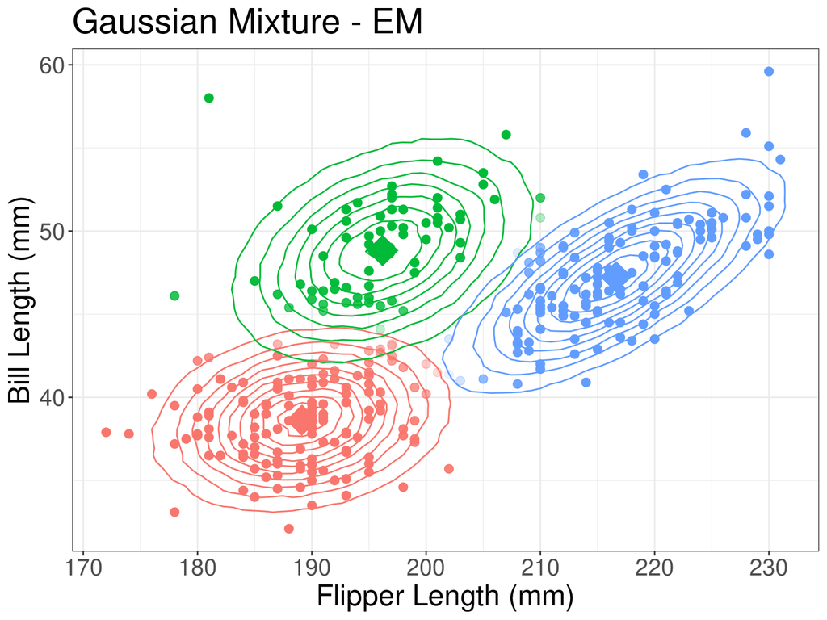

# Alternate K

- What does the 6-component mixture look like?

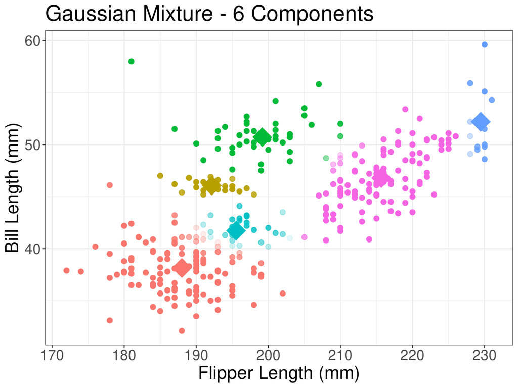

# Challenges with mixture models

- **Highly model dependent** - our identification of the cluster centroids + variances depends heavily on our selection of the appropriate distribution for $Y_i$
  - Normal does okay for outcomes where it’s plausible that CLT kicks in, but not true of all $Y_i$
- **Multi-modality** - Mixture model likelihoods often have multiple modes and EM is only guaranteed to converge to a **local** optimum
  - Can get stuck in a “bad” EM run (**Solution**: Run multiple EM chains with different starting values and pick the one with the best log-likelihood)
  - “Label-switching” problem: Permuting the labels doesn’t change the likelihood
- **Challenges with Bayes** - Sampling-based inference can be tricky with GMMs due to the label-switching problem.
  - Can implement many models via MCMC/Gibbs but need tricks to avoid having the chain jump between permutations.
  - Common to use an approximation to the likelihood around the posterior mode obtained via EM.
  - Stan doesn’t work with discrete variables (can’t take the gradient for HMC)

# Choosing K

- Choosing $K$ is a problem of model comparison and selection.
  - Just as in regression, more parameters = better **in-sample** fit.
  - But we want to avoid **over-fitting**
- Just as before, two approaches
  - **Information criteria** - Evaluate the in-sample log-likelihood at the maximum, penalized by some factor for the number of parameters
  - **Cross-validation** - Estimate the model on a **training set**. Compute the log-likelihood on a **held-out** test set.

# Choosing K

- Log-likelihood doesn’t decrease as K increases, but common to look for an “elbow” where the increases become marginal

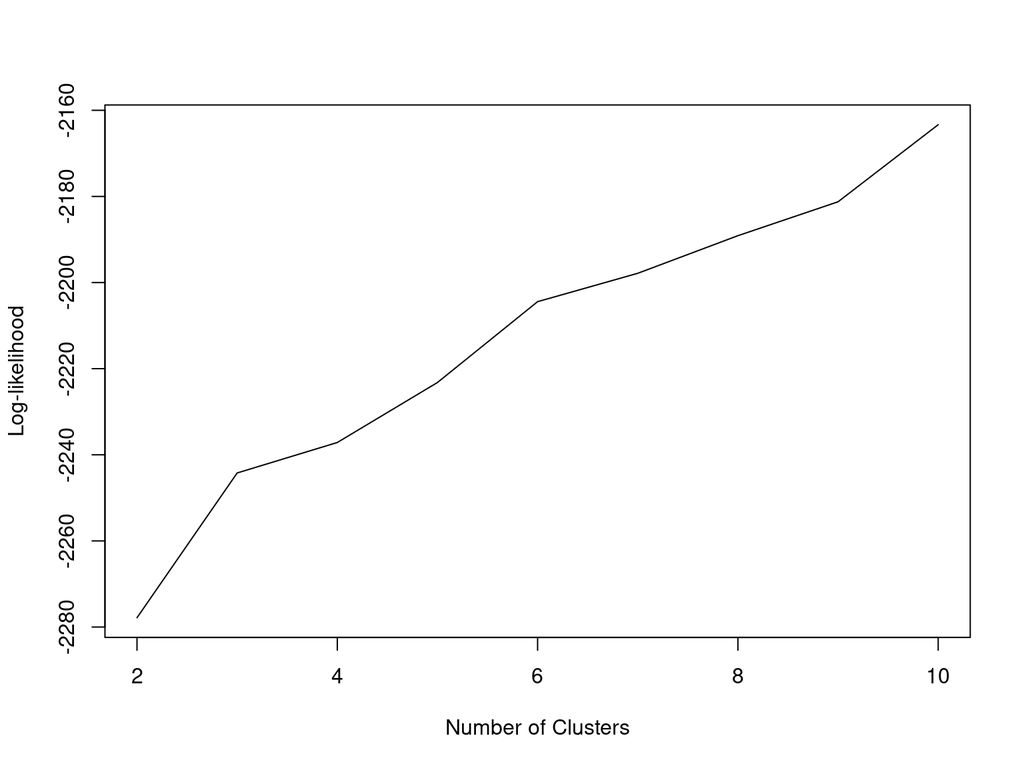

# Choosing K

- Information criteria results depend on how much you penalize the additional parameters
  - $\text{AIC} = 2k - 2\ell(\hat{\theta})$ shows minimal improvement beyond $6$ clusters (but still potentially some!)

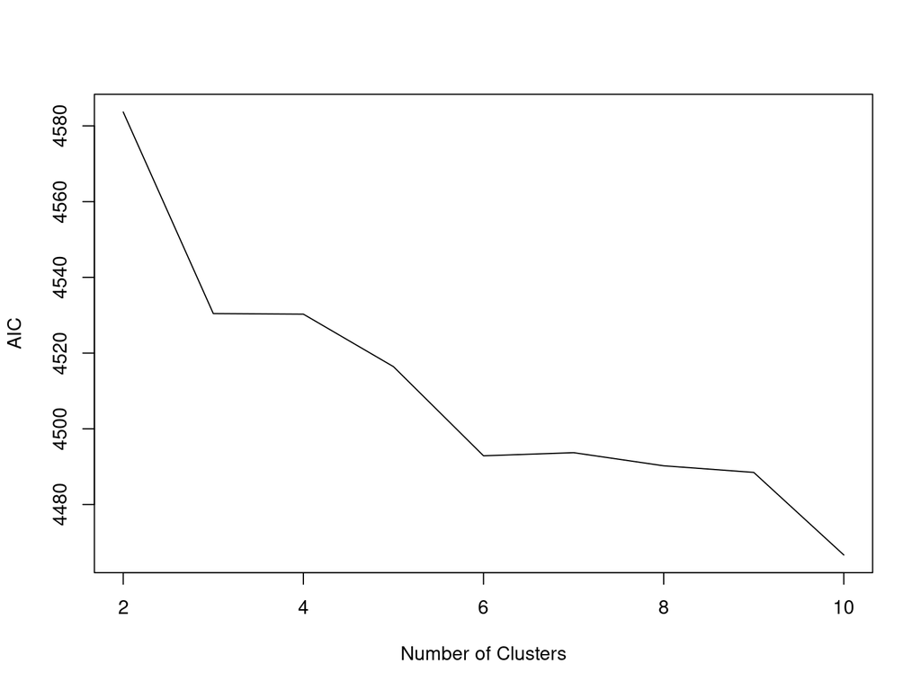

# Choosing K

- 10-fold cross-validation gives best performance at $K=3$

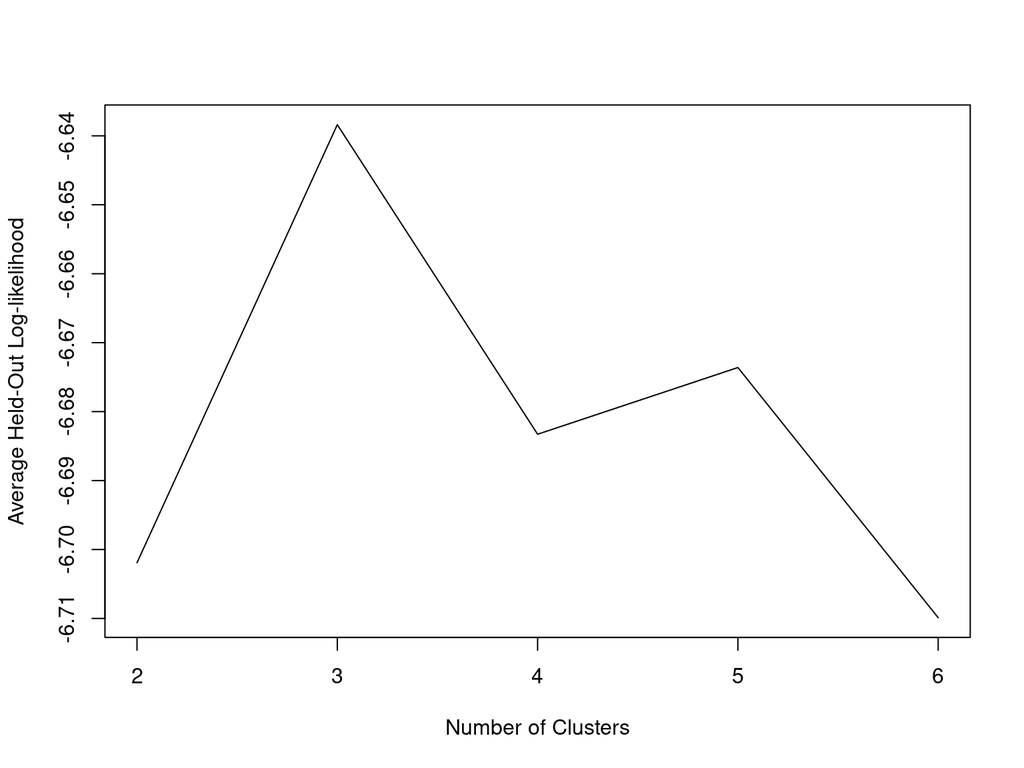

# Topic Modeling

# Modeling Text

- **Topic models** are a tool for **unsupervised** analysis of text
  - Don’t need to label the texts ex-ante.
- Texts are **high-dimensional** - Topic models provide a **lower-dimensional** summary of the common themes in a document
  - Model document content as a **mixture** of a finite number of $K$ latent **topics**
  - Topics are described as a **distribution** on words.
- History of topic models
  - **Latent Dirichlet Allocation** $\leadsto$ **Correlated Topic Model** $\leadsto$ **Structural Topic Model**

# Example: Political Blogs

- Our running example is the CMU 2008 Political Blog corpus (Eisenstein and Xing, 2010)
  - 13,246 posts from 8 political blogs rated liberal/conservative

```
[1] "I honestly don't know how either party's caucus results will play out tonight. Usually, you can get a good idea of perhaps not a winner but at least you can figure out who's up, who's down, and who's on life support.Not with the Iowa Caucuses. Races in both parties are just too close to call. S…
[2] "While we stand in awe of the willingness of our troops in Iraq to sacrifice themselves for the Nation, the fewer that are required to do so, the better.  And the news on that front is good.  As can be seen in the chart below, our military deaths in December dropped to 23 from 37 in November.  D…
[3] "These pages recently said goodbye to global warming.  Ironically, the current spell of global warming, such as it is, can be expected to end just as the Kyoto treaty ends in 2012, but having nothing to do with reduced emissions from fossil fuels.  For the remainder of this century, it will be g…
[4] "A US report shows how the enemy controlled the information on the battlefield in Fallujah and used this to force the US and Iraqi forces out, in the first battle there. The Belmont Club points out UPI coverage of the report by Shaun Waterman. Here is how the enemy worked: First they kidnapped r…
[5] "Mike Huckabee is pretty slick. He's the one Republican who's been boosted by the big media. Those media headlines got him off to a fast start. But a couple of days ago he got the press laughing at his shenanigans with his \"I'm NOT negative!\" press conference. \"Mike Huckabee said Monday he wo…
[6] "In the aftermath of the \"upset\" victories in yesterday's Iowa caucus by Republican Mike Huckabee and Democrat Barack Obama, both the mainstream media and the political commentariat are in a lather over what these results portend for the 2008 presidential race.   The answer:  Very little.The h…
[7] "FrontPage.Com has an editorial up this morning pointing out the deficiencies of both of the Iowa winners last night; Barack Obama and Mike Huckabee:Last night, Iowa caucus-goers had the opportunity to vote for a wide variety of candidates who possessed foreign policy sagacity, an aggressive pla…
[8] "An influential policy outfit, the International Crisis Group, has called on President Musharraf to step down.Citing \"A Way Forward in Pakistan,\" the ICG, which is made up of scholars and former diplomats, believes that the Pakistani president is an obstacle to stability:If Pakistan is to be s…
[9] "Goodbye Iowa for 4 more years. But the Hawkeye State may have crowned the new President this time: Barack Obama. I believe he will be very hard to stop now, both for the nomination and the general election if he is nominated, given how shattered the GOP is (that race is wide open, with a slight…
```

# Pre-processing the text

- We will need to convert the raw documents into a **document-term matrix**
  - **Rows**: Documents
  - **Columns**: “Tokens” (words)
- The `stm` package in R, which implements the **Structural Topic Model** has a host of helper functions for parsing texts and applying conventional pre-processing techniques (stemming, stop word removal, etc…)
  - `textProcessor` wraps the popular `tm` package for text mining

```r
processed <- textProcessor(poliblog$documents, metadata=poliblog,
                           lowercase=T, removestopwords=T,
                           removenumbers = T, removepunctuation=T,
                           stem = T)
```

```r
out <- prepDocuments(processed$documents, processed$vocab, processed$meta,
                     lower.thresh=round(.01*nrow(poliblog)), upper.thresh = round(.99*nrow(poliblog)))
```

```
Removing 121334 of 123990 terms (531226 of 2298953 tokens) due to frequency
Your corpus now has 13246 documents, 2656 terms and 1767727 tokens.
```

# “Bag of Words”

- We summarize each document using the counts of each token
  - These constitute our **document-term matrix** (which software packages typically store in a “sparse” format)

```
     token count
1      ago     1
2    ahead     1
3    along     1
4 although     1
5    among     1
6    anoth     2
```

- The ordering of words is ignored - the “**bag of words**” assumption
  - Can preserve some ordering by tokenizing bigrams or trigrams rather than just unigrams (e.g. “republican party” or “daily tracking poll”)
  - Interestingly, throwing out word order still typically preserves the underlying **topics** or **concepts** in a document!
  - “Modern” extensions would probably use word embeddings

# Latent Dirichlet Allocation

- **Latent Dirichlet Allocation** (Blei, Ng, Jordan, 2003)
  - A generative model for **words** $w$ - defined as unit-vectors from a discrete vocabulary $\{1, 2, \dotsc, V\}$
  - **Documents** are collections of words $\mathbf{w} = \{w_1, w_2, \dotsc w_N\}$
  - A **corpus** is a collection of documents $\{\mathbf{w}_1, \mathbf{w}_2, \dotsc \mathbf{w}_D\}$
- *LDA* assumes a particular generative process for each document $\mathbf{w}_d$:
  1. Choose a **topic proportion** vector $\theta_d \sim \text{Dirichlet}(\alpha)$
  2. For each of the $N$ words in document $d$ $w_{d,n}$
     - Choose topic $z_{d,n} \sim \text{Multinomial}(\theta_d)$
     - Choose word $w_{d,n} \sim \text{Mutinomial}(\beta_{z_{d,n}})$
- Two main targets of inference:
  - The **document topic proportions**: $\theta = \{\theta_1, \theta_2, \dotsc \theta_D\}$
  - The **topic-word distributions**: $\beta = \{\beta_1, \beta_2, \dotsc \beta_k\}$

# Latent Dirichlet Allocation

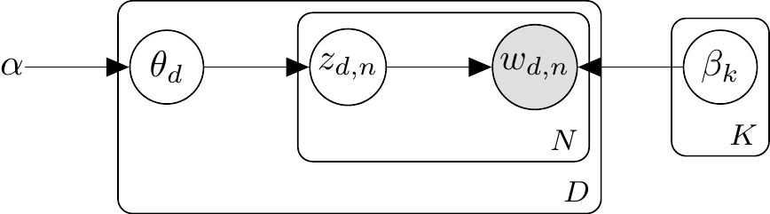

# Correlated Topic Model

- LDA makes a somewhat restrictive assumption on the distribution from where the topics are drawn (the Dirichlet)
  - Topic proportions are assumed to be **independent** (a feature of the dirichlet)
  - But in reality, some topics are more likely to appear with others!
- The **Correlated Topic Model** (Blei and Raftery, 2006) addresses this
  - Replaces the dirichlet with a logistic normal distribution.
- The **Correlated Topic Model** assumes that each document $\mathbf{w}_d$ is generated by:
  1. Draw $\eta_d$ from a **normal distribution** with mean $\mu$, $\Sigma$
  2. For each of the $N$ words $w_{d,n}$
     - Choose topic $z_{d,n} \sim \text{Multinomial}(f(\eta_d))$ where $f(\eta_{d,k}) = \exp(\eta_{d,k})/\sum_{j} \exp(\eta_{d,j})$
     - Choose word $w_{d,n} \sim \text{Mutinomial}(\beta_{z_{d,n}})$

# Correlated Topic Model

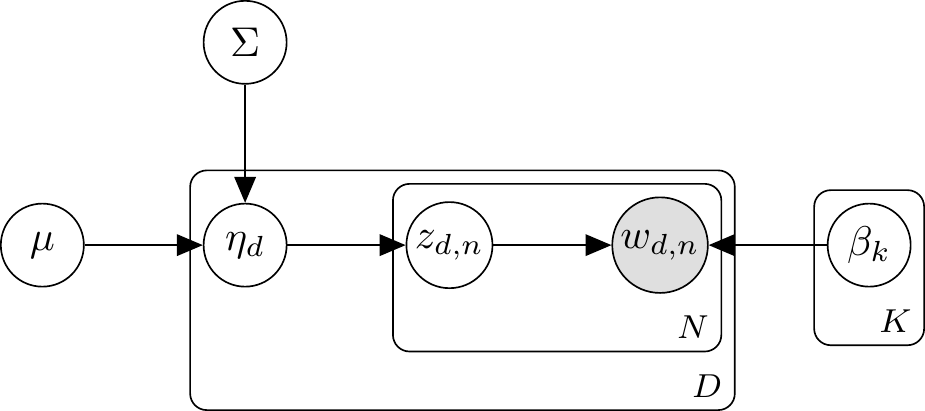

# Structural Topic Model

- Often researchers want to incorporate **covariates** in modeling the topic proportions
  - e.g. - Do Liberal blogs talk about different topics compared to Conservative blogs?
  - Ad-hoc regressions of topic proportions on covariates will fail to incorporate uncertainty in the estimation of the topics.
- Additionally, researchers may want to have different word distributions for a topic depending on covariates
  - e.g. - Do Liberal blogs talk *about immigration* differently than Conservative blogs?
- The **Structural Topic Model** (Roberts, Stewart, Tingley, Airoldi, 2013) extends the correlated topic model to incorporate covariates:
  - Allow covariates $X_d$ to enter into the logistic-normal distribution governing the topic proportions $\eta_d \sim \text{Normal}(\mu_{d}, \Sigma)$ where $\mu_{d,k} = X_{d}^{\prime}\gamma_{k}$
  - Allow covariates $Y_d$ to enter into the $\beta$ parameter governing topic content $\beta_{d, k} \propto \exp(m + \kappa_k^{(t)} + \kappa_{y_d}^{(c)} + \kappa_{y_d,k}^{(i)})$

# Structural Topic Model

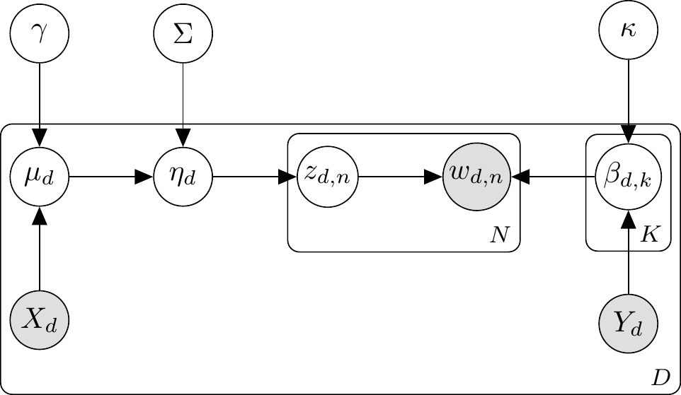

# Illustration: Political Texts

- Without any covariates, `stm()` is a fast implementation of the **correlated topic model**

```r
poliBlog_fit <- stm(documents = out$documents,
                    vocab = out$vocab,
                    K = 20, verbose=F,
                    max.em.its = 75, data = out$meta,
                    init.type = "Spectral", seed=60639)
```

- `stm()` implements a **Variational EM** algorithm to provide a tractable, analytical approximation to the posterior distribution
  - **Benefits**: Faster, deterministic
  - **Drawbacks**: Can understate the variance in the posterior
  - For more, see: Grimmer, 2010 “An Introduction to Bayesian Inference via Variational Approximations” *Political Analysis*

# Illustration: Political Texts

- Typically, we’re interested in understanding the content of the topics discovered
  - We’ll inspect the **topic-word** distributions to attempt to infer the underlying topic meaning from a set of “top” words

```
Topic 20 Top Words:
     Highest Prob: financi, crisi, market, govern, money, bank, bailout
     FREX: financi, bailout, loan, mortgag, bank, fanni, market
     Lift: mae, fanni, paulson, freddi, subprim, treasuri, bailout
     Score: mae, bailout, mortgag, fanni, financi, loan, market
```

- Common criteria for ranking the “top” words
  - **Highest probability** - Which words have the highest probability in the topic-word distribution $\beta_{k} = p(w | z = k)$
  - **Frequency-Exclusivity** (FREX) - Harmonic mean of rank by within-topic probability and rank by topic distribution given word $p(z | w = v)$
  - **Lift** - Topic-word distribution divided by the empirical distribution - how **more common** are these words in this topic relative to their baseline prevalence)
  - **Score** - Similar to Lift (but in terms of log probabilities)

# Illustration: Political Texts

- We can find “prototypical” documents that contain a high proportion of a particular topic

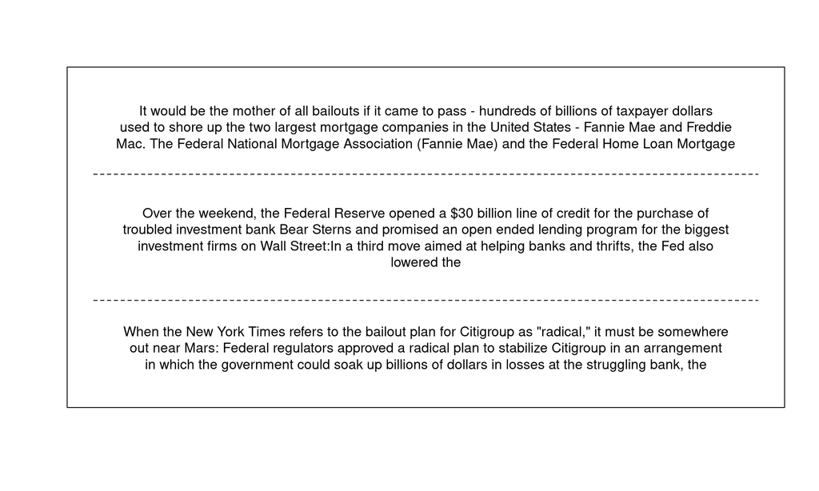

# Illustration: Political Texts

- What about this topic?

```
Topic 16 Top Words:
     Highest Prob: will, american, care, health, america, peopl, can
     FREX: care, health, job, america, famili, educ, that
     Lift: coal, health, prosper, poverti, care, insur, afford
     Score: coal, health, tax, care, economi, american, insur
```

# Illustration: Political Texts

- Not all topics make sense

```
Topic 4 Top Words:
     Highest Prob: get, one, ’re, don’t, like, want, doesn’t
     FREX: doesn’t, ’ll, ’re, don’t, didn’t, can’t, ’ve
     Lift: chat, see-dubya, ’ll, one’, can’t, isn’t, doesn’t
     Score: chat, ’re, ’ll, don’t, doesn’t, ’ve, didn’t
```

# Illustration: Political Texts

- Topic 4 seems to be picking up some odd stylistic feature of Minnesota conservative talk radio?

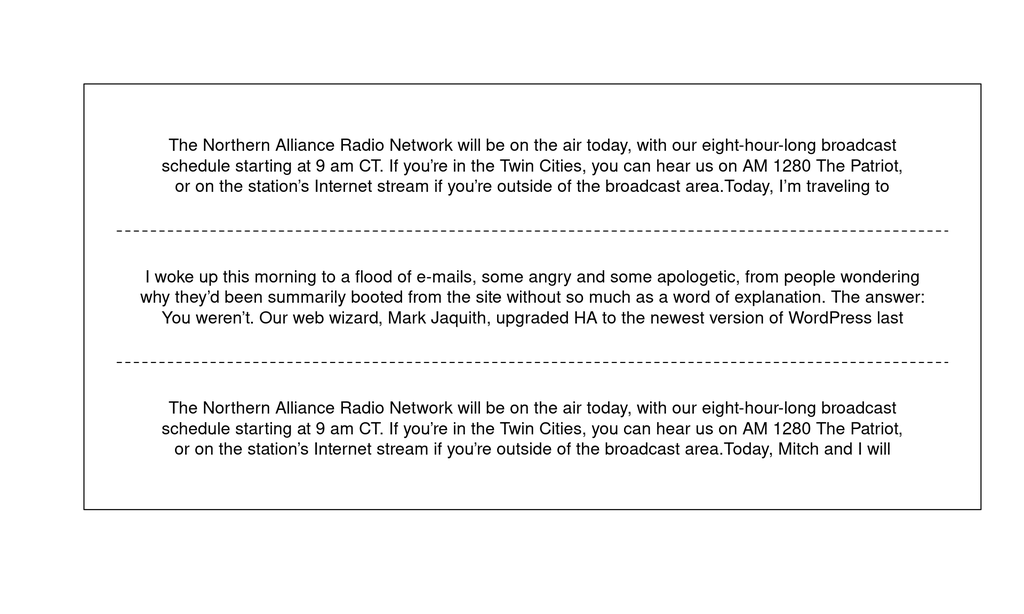

# Choosing Models

- How do we evaluate the quality of a model?
  - …for multiple runs of the same topic count (multiple modes)
  - …for different numbers of topics?
- Conventional method: **held-out log-likelihood**. For an “out-of-sample” document $\mathbf{w}_{\text{out}}$:

$$\text{Perplexity} = \exp(-\log p(\mathbf{w}_{\text{out}}| \mu, \Sigma, \beta))$$

- But “highly predictive” topic models may be difficult for humans to interpret (Chang et. al., 2009).

# Coherence and Exclusivity

- **Alternative** - Pick models where the topics have nice features
  - **Semantic coherence** - The most common words in a topic tend to co-occur in a document
  - **Exclusivity** - Words that have high probability in a topic have low probability in **other** topics (FREX).
- **Semantic coherence**
  - Let $D(v, v^{\prime})$ define the number of times words $v$ and $v^{\prime}$ appear together in a document.
  - Semantic coherence is defined as a sum across the $W$ most probable words

$$C_k = \sum_{i=2}^W \sum_{j=1}^{i-1} \log \bigg( \frac{D(v_i, v_j) + 1}{D(v_j)}\bigg)$$

# Illustration: Political Texts

- Let’s compare fits across 10, 20, 30, and 40 topics

```r
modelEval <- searchK(out$documents,
                    vocab = out$vocab,
                    K = c(10,20,30,40), verbose=F,
                    max.em.its = 75, data = out$meta,
                    init.type = "Spectral", seed=60639, cores=4)
```

```
Using multiple-cores.  Progress will not be shown.
```

# Illustration: Political Texts

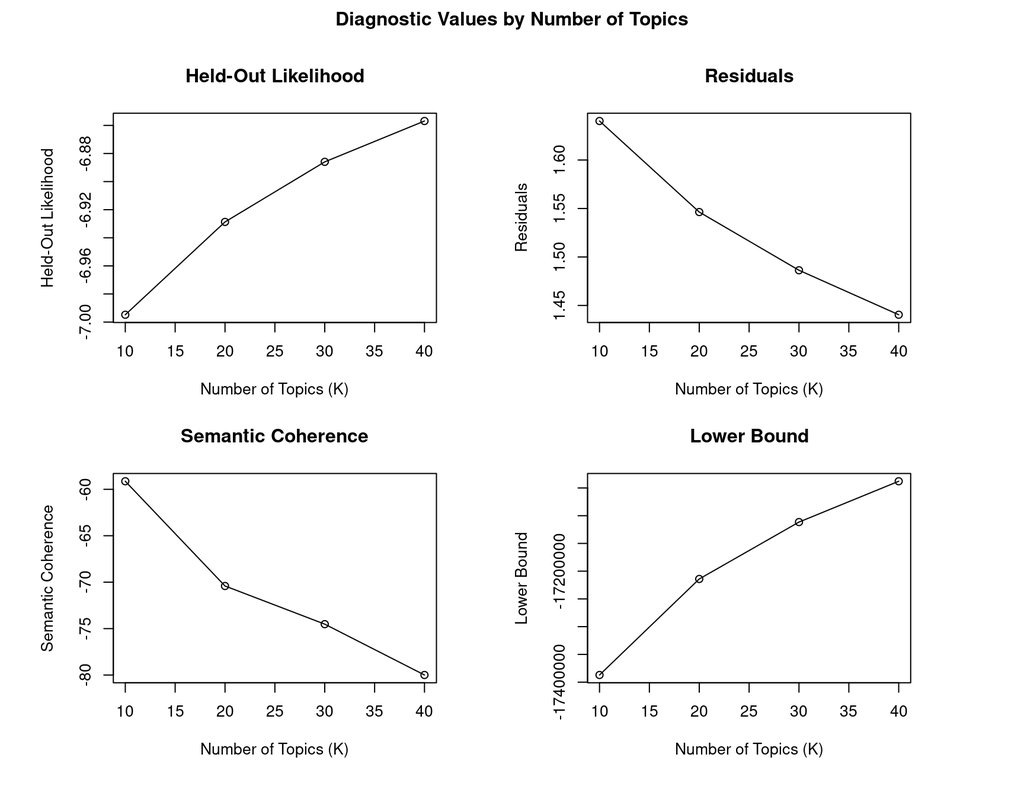

# Illustration: Political Texts

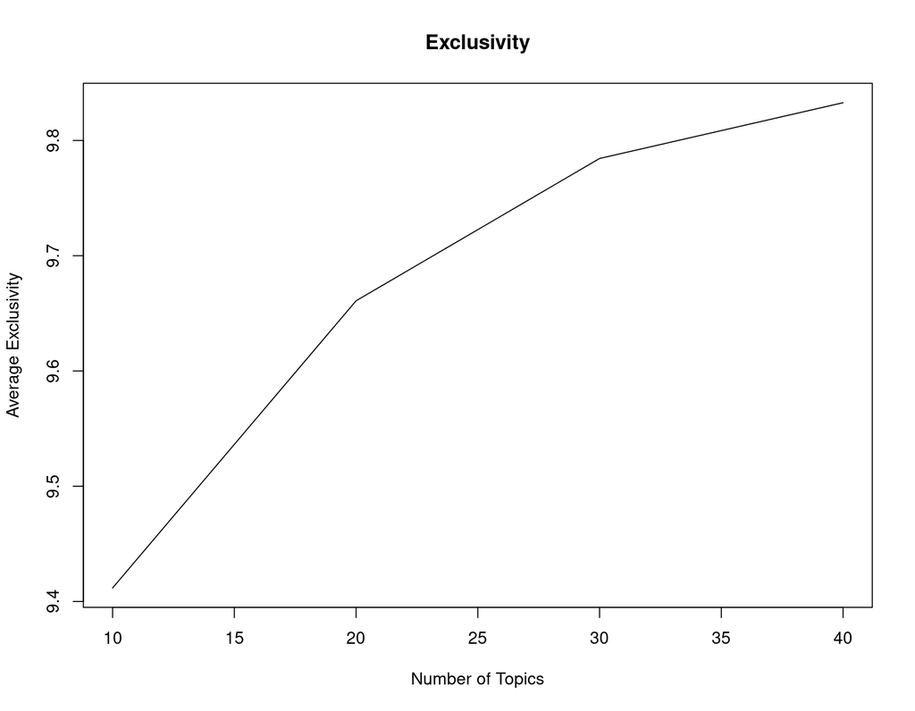

# Estimating coefficients

- With `stm()`, we can incorporate covariates into the topic proportions using standard formula syntax

```r
poliBlog_fit_cov <- stm(documents = out$documents,
                    vocab = out$vocab,
                    prevalence = ~ rating,
                    K = 20, verbose=F,
                    max.em.its = 75, data = out$meta,
                    init.type = "Spectral", seed=60639)
```

# Estimating coefficients

- Do liberal blogs talk about health care more than conservative blogs?

```r
estim_hc <- estimateEffect(c(16) ~ rating, stmobj=poliBlog_fit_cov, metadata=out$meta)
summary(estim_hc)
```

```
Call:
estimateEffect(formula = c(16) ~ rating, stmobj = poliBlog_fit_cov,
    metadata = out$meta)


Topic 16:

Coefficients:
              Estimate Std. Error t value Pr(>|t|)
(Intercept)   0.031058   0.001170   26.55   <2e-16 ***
ratingLiberal 0.021657   0.001824   11.87   <2e-16 ***
---
Signif. codes:  0 '***' 0.001 '**' 0.01 '*' 0.05 '.' 0.1 ' ' 1
```

# Estimating coefficients

- Do conservative blogs talk about the financial crisis more than liberal blogs?

```r
estim_fc <- estimateEffect(c(20) ~ rating, stmobj=poliBlog_fit_cov, metadata=out$meta)
summary(estim_fc)
```

```
Call:
estimateEffect(formula = c(20) ~ rating, stmobj = poliBlog_fit_cov,
    metadata = out$meta)


Topic 20:

Coefficients:
               Estimate Std. Error t value Pr(>|t|)
(Intercept)    0.040075   0.001302  30.787  < 2e-16 ***
ratingLiberal -0.005467   0.002097  -2.607  0.00914 **
---
Signif. codes:  0 '***' 0.001 '**' 0.01 '*' 0.05 '.' 0.1 ' ' 1
```